# Dhx9 RNAseq : Differential expression

@vivekbhr

Wed Jun 29 16:30:21 2016

### Gene counts

For poly-A samples the library had 40-50 Mil reads. ~90% mapped and >70% counted (30-40Mil). Except for one sample: **HEK_s4019_4** which had only 17 Mil reads and 12Mil were counted at the end.

For poly-A minus samples the library had around 30-40 Mil reads. ~85% mapped and ~30% counted into genes (8-12 Mil).

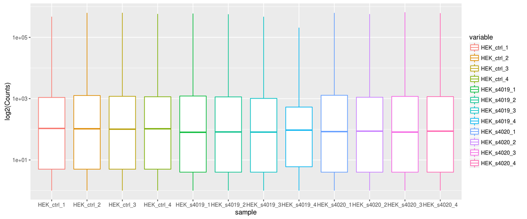

## DESeq2 on poly-A transcripts

Results and plots saved under folder DESeq_results/samplewise. I have used DDR20 to denote siRNA 4020, and DDR19 to denote siRNA 4019.

### Visualize the outputs

#### Number of affected genes

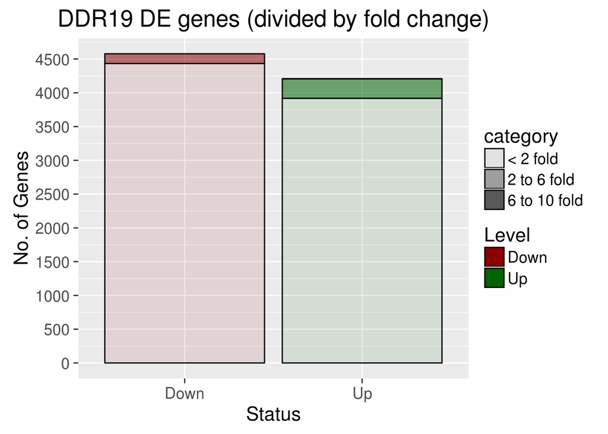

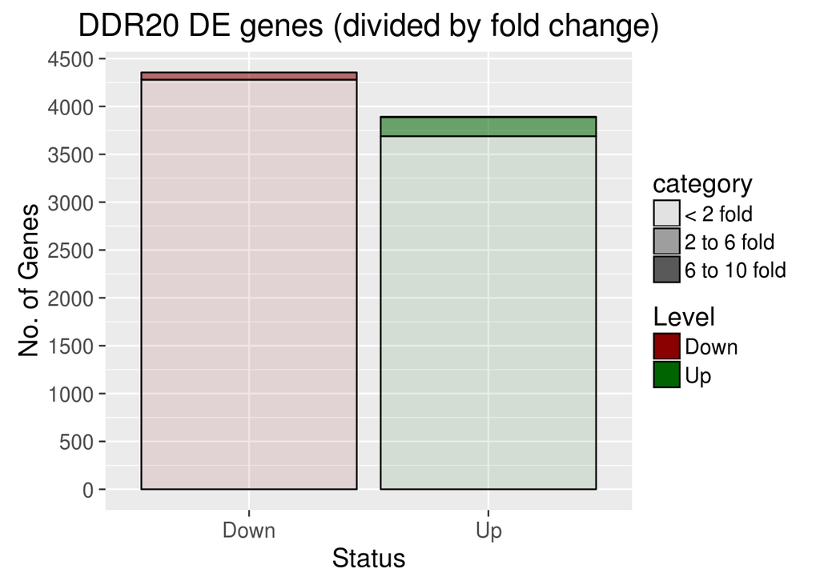

#### Overlap between siRNAs

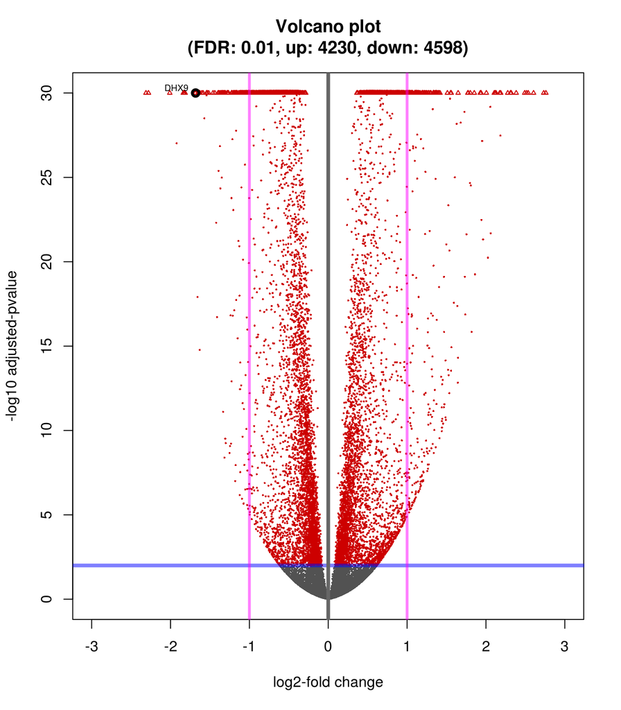

The numbers are shown below.

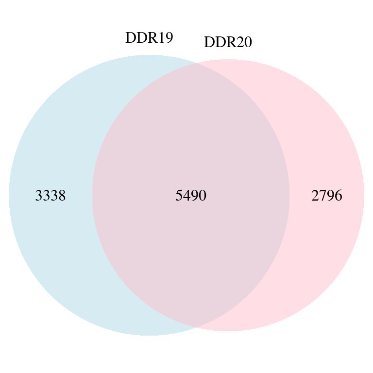

[output not shown]

#### Overlap with Old KD

How do new KDs compare to previous knockdown? We can see that in my SetPlot below.

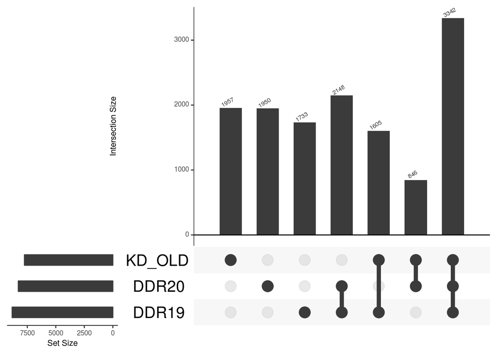

Was the old KD done with DDR19 siRNA?

### Conclusions

- DE analysis gives same number of genes as before (8-9k).
- Around 5.5K genes overlap bw siRNAs and 3.3K with old data. So around 3-4k genes are probably reproducibly affected.
- THESE RESULTS ARE HERE ONLY FOR COMPARISON. NOT TO BE USED IN FINAL ANALYSIS..